# A股惊现7大黄金坑,黄金坑里藏黄金

# 黄金坑 航空运输

[figure not shown]

> 白菜价,特点需要长时间低成本资金大额买入低价白菜！！

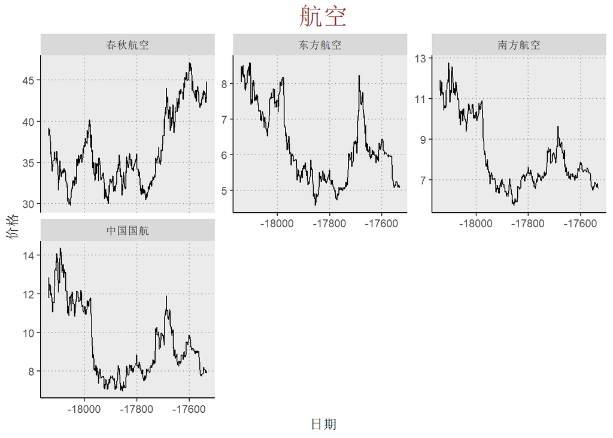

# 黄金坑 天然气

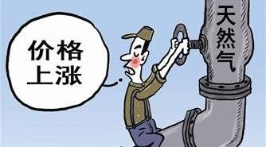

> 国庆大阅兵,环保先行,燃气公司被动扩张,城中村，城边村开始集中供暖,LNG天然气的价格上涨,本质上只需要西伯利亚的寒风一吹,雪花一飘,燃气瞬间涨停.

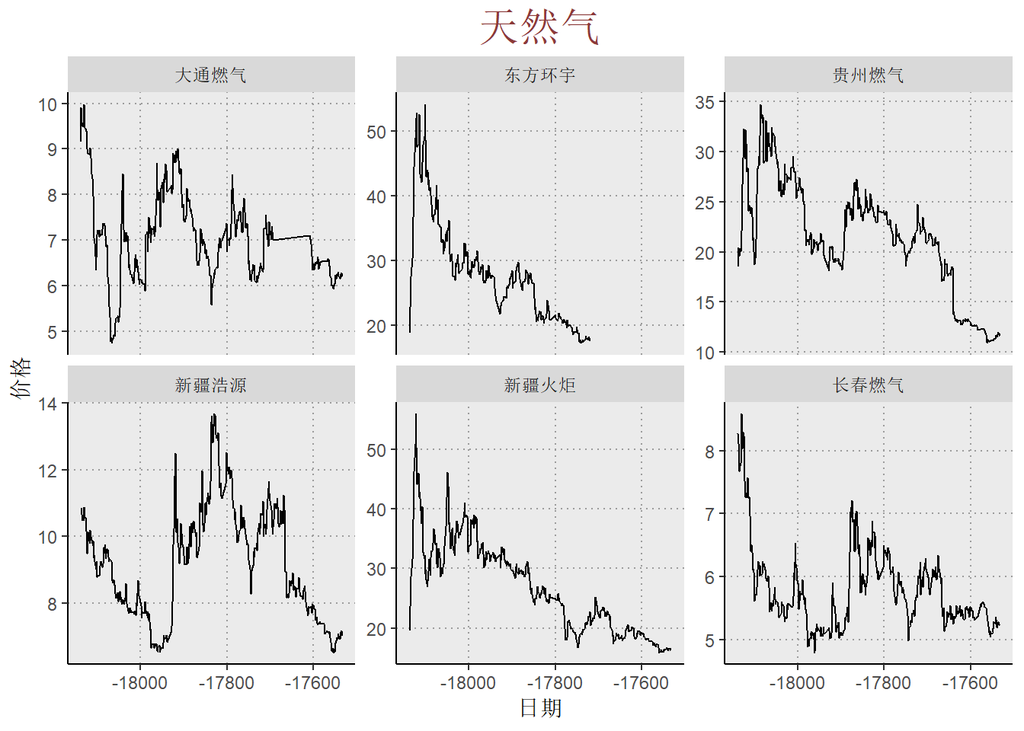

# 黄金坑 银行板块

> 打个广告,关注民生银行第一大股东之争,华夏人寿能否上位,安邦人寿能否让贤

[figure not shown]

> 根据申万一级行业市盈率显示的数据,银行业最新的市盈率仅为6.61（8月20日数据）,基本处于历史相对最低位的阶段,具有较高的安全边际. 上半年大部分银行贷款不良率下降，净利润增加，虽然也受到经济下行压力影响,但总体经营稳健,特别是随着下半年货币政策保持流动性合理充裕态势下，业绩仍有提升空间.展望后市，市场整体风险偏好保持低位，银行板块的业绩确定性优势以及部分个股较高的股息率有助于板块估值的稳定,以及保持行业间的相对优势，适合中长期配置. 重点关注股票 招商银行,平安银行,兴业银行,建设银行

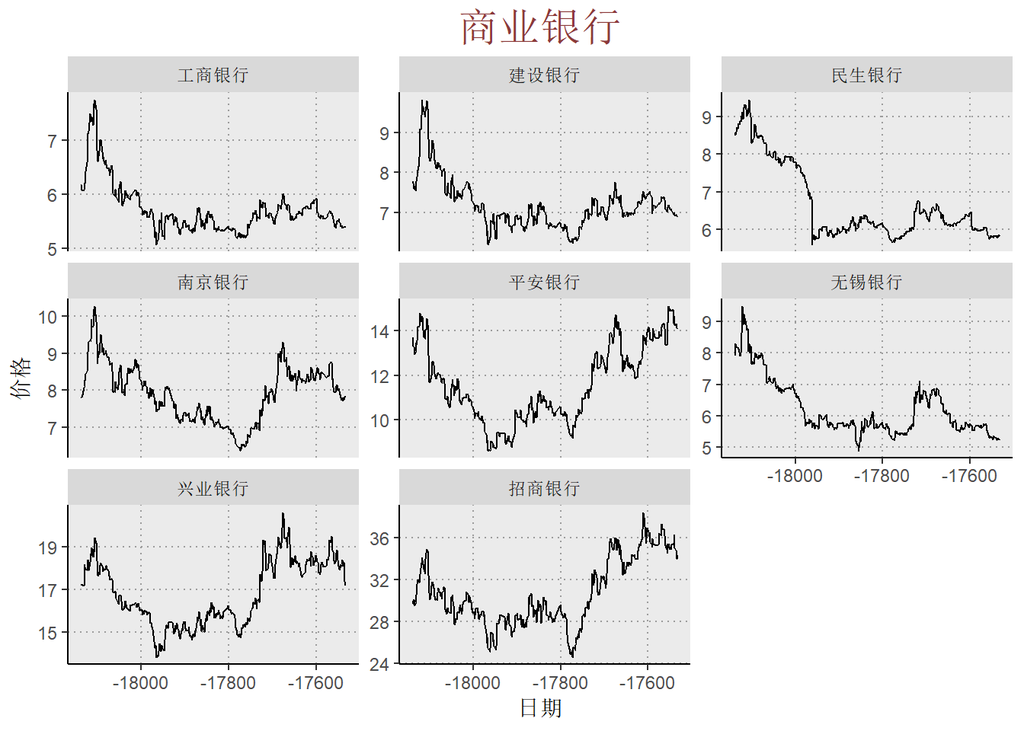

# 黄金坑 国电改革

> 国家电力改革,影响深远,着眼于未来,利在千秋万代! 直购模式与传统电力购买模式,将激发电力企业的活力.

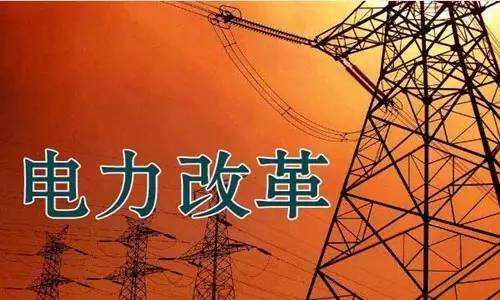

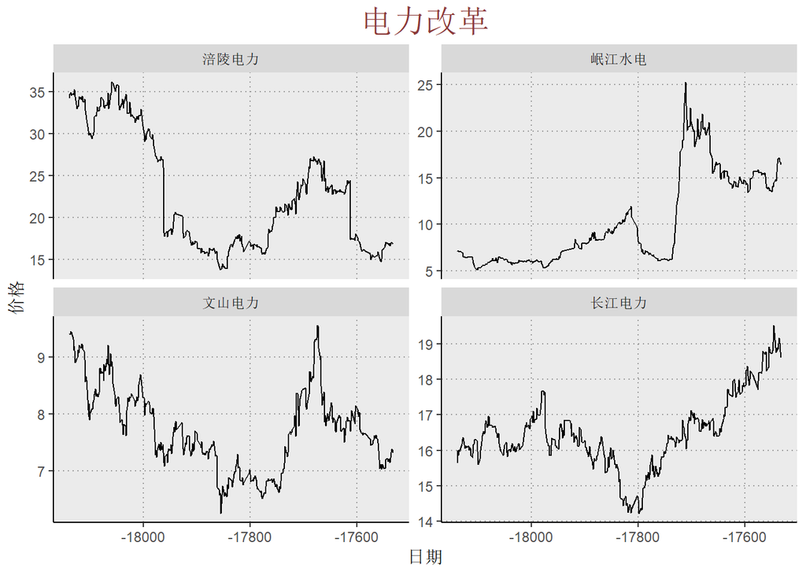

# 火山口 北上资金

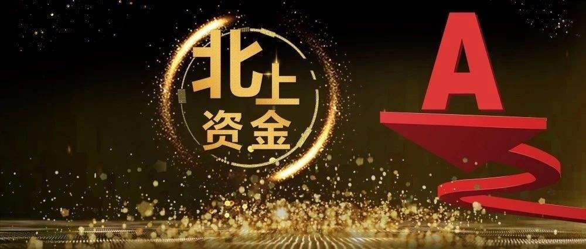

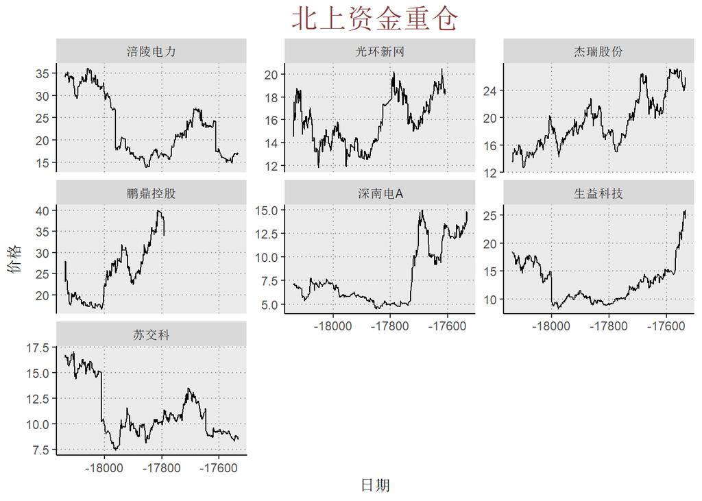

# 火山口 QFII外资重仓

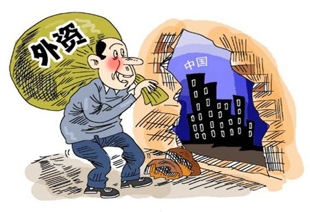

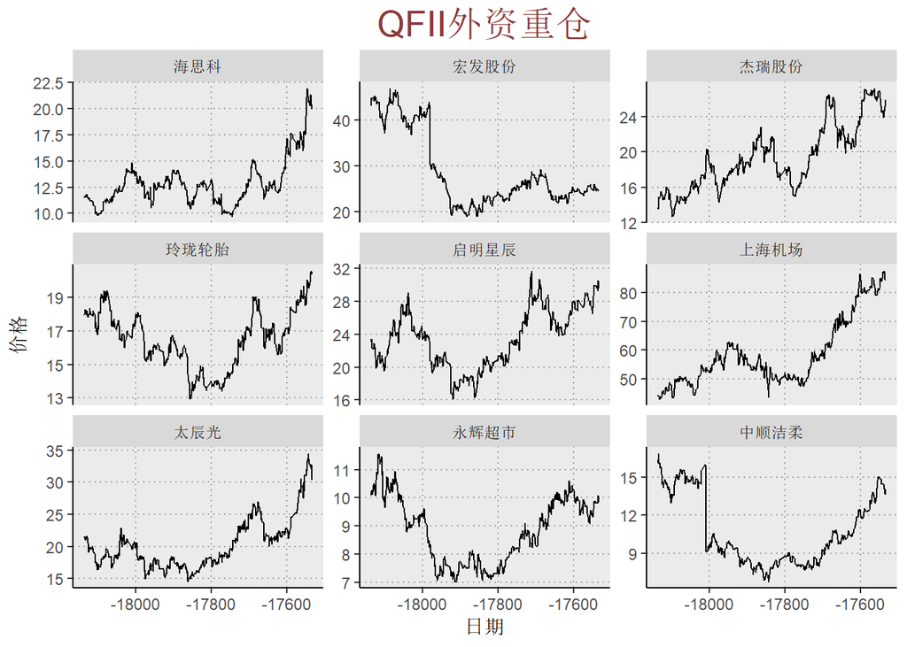

# 火山口 军工大飞机

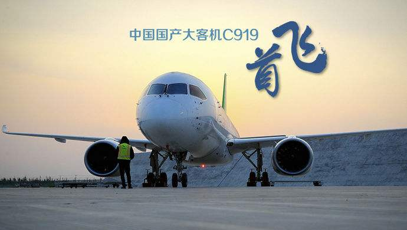

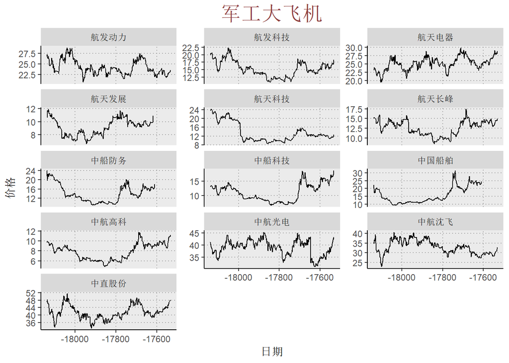

# 火山口 北斗卫星

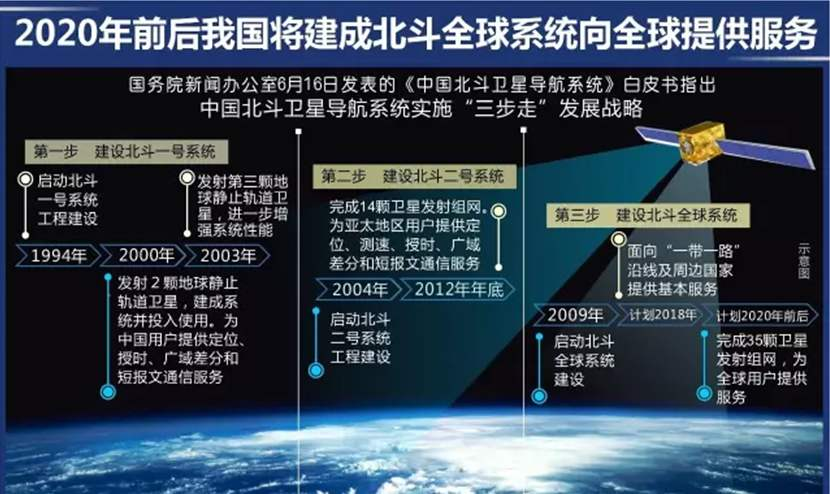

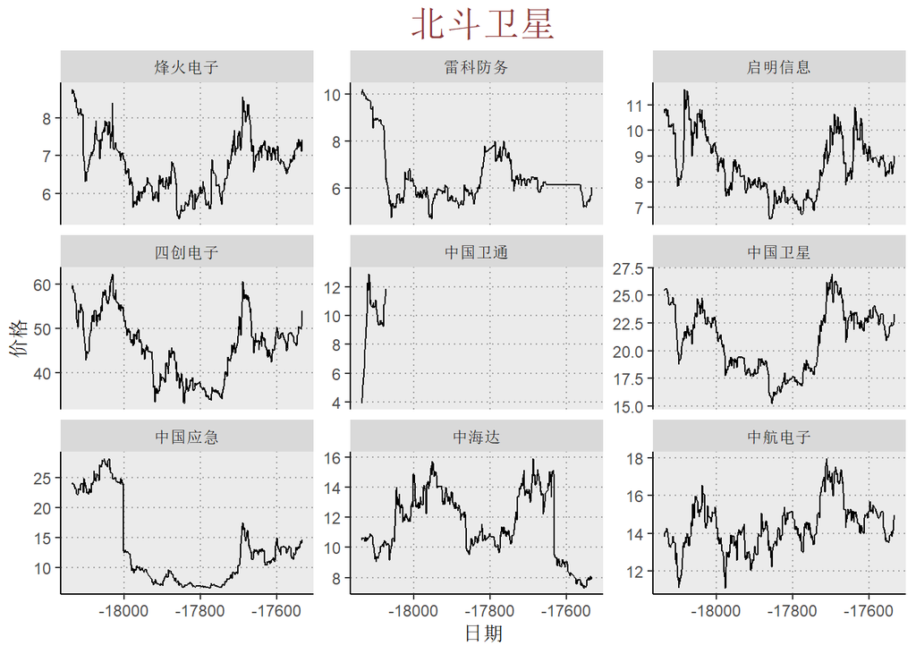

# 风口浪尖 喝酒吃药

[figure not shown]

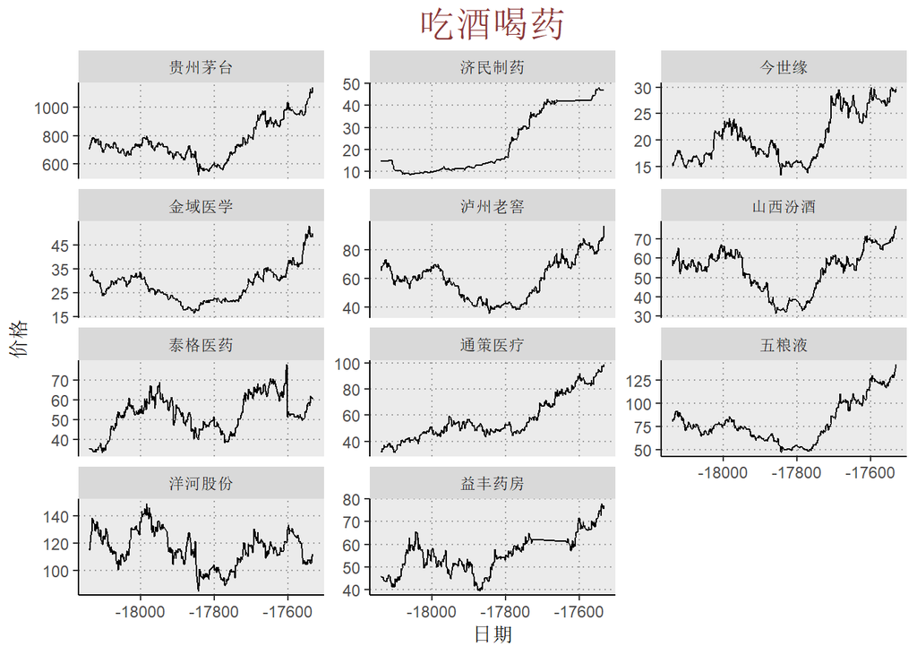

```
风险最大时,也是机遇最大时.别人恐惧时,我们要贪婪！！

如果说科技股是前锋马龙,那么军工科技将是大前锋邓肯,券商只能做后卫哈登！！
```

[figure not shown]

# 本周投资策略

> 以改革促降息，科技股积极可为 内外部环境仍相对温和，积极信号进一步增多，结构性机会积极可为：外部环境看，美国期限利差倒挂预示美国经济下行压力和美国波动压力，对A股影响有限。内部环境看，LPR机制形成，以利率市场化改革方式促降息，有望引导实体经济融资成本下行，叠加减税降费等政策效果的逐步显现，企业成本费用端压力有望进一步降低，市场风险偏好有望改善；8月以来，国内长端利率明显下行，创2017年以来新低。配置上，继续推荐科技股+汽车，优选华为产业链+半导体产业链。

# 投资大师的成功法则

大师最初也是初学者,跟随大师的脚步才能快速成长.

> “集中投资就是计划生育:股票越少，组合业绩越好;长期持有就是龟兔赛跑:长期内复利可以战胜一切;”

# 投资建议

> 1 采用金字塔式投资策略,震荡的行情中按比例1:2:3:4分布建仓！

> 2 延长持有周期,追求一定周期内的绝对投资回报！

> 3 投资有风险,投资需谨慎！！